# CS634 Final Project

Name: Pablo Salar Carrera  
UCID: ps2255  
Instructor: Dr. Yasser  
Class: CS634

## Tutorial:

```python
import numpy as np
import pandas as pd
import matplotlib.pyplot as plt
import seaborn as sbn
from sklearn.model_selection import train_test_split
from sklearn.preprocessing import StandardScaler, LabelEncoder
from sklearn.preprocessing import RobustScaler
from sklearn.ensemble import RandomForestClassifier
from sklearn.naive_bayes import GaussianNB
from sklearn.model_selection import GridSearchCV
from sklearn.model_selection import StratifiedKFold
from sklearn.metrics import confusion_matrix
from sklearn.metrics import roc_auc_score, roc_curve
from sklearn.metrics import brier_score_loss
from sklearn.metrics import auc
from sklearn.neighbors import KNeighborsClassifier
from tensorflow.keras.models import Sequential
from tensorflow.keras.layers import LSTM, Dense, Dropout, Input
from tensorflow.keras.utils import to_categorical
from imblearn.over_sampling import SMOTE
```

```
2024-11-24 23:35:16.741728: I tensorflow/core/platform/cpu_feature_guard.cc:210] This TensorFlow binary is optimized to use available CPU instructions in performance-critical operations.
To enable the following instructions: AVX2 FMA, in other operations, rebuild TensorFlow with the appropriate compiler flags.
```

Dataset link:  
https://www.kaggle.com/datasets/iamsouravbanerjee/heart-attack-prediction-dataset?resource=download

```python
dataset = pd.read_csv('salar_pablo_finaltermproj.csv', index_col = 0)
```

```python
dataset.head()
```

| Patient ID | Age | Sex | Cholesterol | Blood Pressure | Heart Rate | Diabetes | Family History | Smoking | Obesity | Alcohol Consumption | ... | Sedentary Hours Per Day | Income | BMI | Triglycerides | Physical Activity Days Per Week | Sleep Hours Per Day | Country | Continent | Hemisphere | Heart Attack Risk |
| --- | --- | --- | --- | --- | --- | --- | --- | --- | --- | --- | --- | --- | --- | --- | --- | --- | --- | --- | --- | --- | --- |
| BMW7812 | 67 | Male | 208 | 158/88 | 72 | 0 | 0 | 1 | 0 | 0 | ... | 6.615001 | 261404 | 31.251233 | 286 | 0 | 6 | Argentina | South America | Southern Hemisphere | 0 |
| CZE1114 | 21 | Male | 389 | 165/93 | 98 | 1 | 1 | 1 | 1 | 1 | ... | 4.963459 | 285768 | 27.194973 | 235 | 1 | 7 | Canada | North America | Northern Hemisphere | 0 |
| BNI9906 | 21 | Female | 324 | 174/99 | 72 | 1 | 0 | 0 | 0 | 0 | ... | 9.463426 | 235282 | 28.176571 | 587 | 4 | 4 | France | Europe | Northern Hemisphere | 0 |
| JLN3497 | 84 | Male | 383 | 163/100 | 73 | 1 | 1 | 1 | 0 | 1 | ... | 7.648981 | 125640 | 36.464704 | 378 | 3 | 4 | Canada | North America | Northern Hemisphere | 0 |
| GFO8847 | 66 | Male | 318 | 91/88 | 93 | 1 | 1 | 1 | 1 | 0 | ... | 1.514821 | 160555 | 21.809144 | 231 | 1 | 5 | Thailand | Asia | Northern Hemisphere | 0 |

5 rows × 25 columns

```python
dataset.shape
```

```
(8763, 25)
```

```python
dataset.dtypes
```

```
Age                                  int64
Sex                                 object
Cholesterol                          int64
Blood Pressure                      object
Heart Rate                           int64
Diabetes                             int64
Family History                       int64
Smoking                              int64
Obesity                              int64
Alcohol Consumption                  int64
Exercise Hours Per Week            float64
Diet                                object
Previous Heart Problems              int64
Medication Use                       int64
Stress Level                         int64
Sedentary Hours Per Day            float64
Income                               int64
BMI                                float64
Triglycerides                        int64
Physical Activity Days Per Week      int64
Sleep Hours Per Day                  int64
Country                             object
Continent                           object
Hemisphere                          object
Heart Attack Risk                    int64
dtype: object
```

Let's check for missing values and duplicates in the dataset.

```python
dataset.isna().sum()
```

```
Age                                0
Sex                                0
Cholesterol                        0
Blood Pressure                     0
Heart Rate                         0
Diabetes                           0
Family History                     0
Smoking                            0
Obesity                            0
Alcohol Consumption                0
Exercise Hours Per Week            0
Diet                               0
Previous Heart Problems            0
Medication Use                     0
Stress Level                       0
Sedentary Hours Per Day            0
Income                             0
BMI                                0
Triglycerides                      0
Physical Activity Days Per Week    0
Sleep Hours Per Day                0
Country                            0
Continent                          0
Hemisphere                         0
Heart Attack Risk                  0
dtype: int64
```

```python
dataset.duplicated().sum()
```

```
0
```

There are no missing values or duplicates, therefore we can continue analyzing the data.

Let's see how the numerical columns are distributed

```python
dataset.describe()
```

|  | Age | Cholesterol | Heart Rate | Diabetes | Family History | Smoking | Obesity | Alcohol Consumption | Exercise Hours Per Week | Previous Heart Problems | Medication Use | Stress Level | Sedentary Hours Per Day | Income | BMI | Triglycerides | Physical Activity Days Per Week | Sleep Hours Per Day | Heart Attack Risk |
| --- | --- | --- | --- | --- | --- | --- | --- | --- | --- | --- | --- | --- | --- | --- | --- | --- | --- | --- | --- |
| count | 8763.000000 | 8763.000000 | 8763.000000 | 8763.000000 | 8763.000000 | 8763.000000 | 8763.000000 | 8763.000000 | 8763.000000 | 8763.000000 | 8763.000000 | 8763.000000 | 8763.000000 | 8763.000000 | 8763.000000 | 8763.000000 | 8763.000000 | 8763.000000 | 8763.000000 |
| mean | 53.707977 | 259.877211 | 75.021682 | 0.652288 | 0.492982 | 0.896839 | 0.501426 | 0.598083 | 10.014284 | 0.495835 | 0.498345 | 5.469702 | 5.993690 | 158263.181901 | 28.891446 | 417.677051 | 3.489672 | 7.023508 | 0.358211 |
| std | 21.249509 | 80.863276 | 20.550948 | 0.476271 | 0.499979 | 0.304186 | 0.500026 | 0.490313 | 5.783745 | 0.500011 | 0.500026 | 2.859622 | 3.466359 | 80575.190806 | 6.319181 | 223.748137 | 2.282687 | 1.988473 | 0.479502 |
| min | 18.000000 | 120.000000 | 40.000000 | 0.000000 | 0.000000 | 0.000000 | 0.000000 | 0.000000 | 0.002442 | 0.000000 | 0.000000 | 1.000000 | 0.001263 | 20062.000000 | 18.002337 | 30.000000 | 0.000000 | 4.000000 | 0.000000 |
| 25% | 35.000000 | 192.000000 | 57.000000 | 0.000000 | 0.000000 | 1.000000 | 0.000000 | 0.000000 | 4.981579 | 0.000000 | 0.000000 | 3.000000 | 2.998794 | 88310.000000 | 23.422985 | 225.500000 | 2.000000 | 5.000000 | 0.000000 |
| 50% | 54.000000 | 259.000000 | 75.000000 | 1.000000 | 0.000000 | 1.000000 | 1.000000 | 1.000000 | 10.069559 | 0.000000 | 0.000000 | 5.000000 | 5.933622 | 157866.000000 | 28.768999 | 417.000000 | 3.000000 | 7.000000 | 0.000000 |
| 75% | 72.000000 | 330.000000 | 93.000000 | 1.000000 | 1.000000 | 1.000000 | 1.000000 | 1.000000 | 15.050018 | 1.000000 | 1.000000 | 8.000000 | 9.019124 | 227749.000000 | 34.324594 | 612.000000 | 5.000000 | 9.000000 | 1.000000 |
| max | 90.000000 | 400.000000 | 110.000000 | 1.000000 | 1.000000 | 1.000000 | 1.000000 | 1.000000 | 19.998709 | 1.000000 | 1.000000 | 10.000000 | 11.999313 | 299954.000000 | 39.997211 | 800.000000 | 7.000000 | 10.000000 | 1.000000 |

```python
for column in dataset.columns:
    unique_values = dataset[column].unique()
    print(f"Unique values in '{column}': {unique_values}")
    print()
```

```
Unique values in 'Age': [67 21 84 66 54 90 20 43 73 71 77 60 88 69 38 50 45 36 48 40 79 63 27 25
 86 42 52 29 30 47 44 33 51 70 85 31 56 24 74 72 55 26 53 46 57 22 35 39
 80 65 83 82 28 19 75 18 34 37 89 32 49 23 59 62 64 61 76 41 87 81 58 78
 68]

Unique values in 'Sex': ['Male' 'Female']

Unique values in 'Cholesterol': [208 389 324 383 318 297 358 220 145 248 373 374 228 259 122 379 166 303
 340 294 359 202 133 159 271 273 328 154 135 197 321 375 360 263 201 347
 129 229 251 121 190 185 279 336 192 180 203 368 222 243 218 120 285 377
 369 311 139 266 153 339 329 333 398 124 183 163 362 390 200 396 255 209
 247 250 227 246 223 330 195 194 178 155 240 237 216 276 224 326 198 301
 314 304 334 213 254 230 316 277 388 206 384 205 261 308 338 382 291 168
 171 378 253 245 226 281 123 173 231 234 268 306 186 293 161 380 239 149
 320 219 335 265 126 307 270 225 193 148 296 136 364 353 252 232 387 299
 357 214 370 345 351 344 152 150 131 272 302 337 170 356 274 188 125 138
 376 181 184 275 394 128 217 399 283 289 284 327 262 212 350 385 162 141
 361 244 295 287 144 354 363 352 140 196 172 319 325 331 392 147 187 346
 286 151 300 165 343 366 317 386 158 157 242 241 365 257 348 175 298 269
 267 397 310 341 204 127 290 280 132 322 179 199 143 312 288 395 189 156
 238 381 391 355 210 400 260 235 167 256 249 207 130 134 137 305 236 315
 292 323 146 258 332 372 142 309 177 367 371 211 282 342 264 176 160 233
 313 164 349 221 191 174 393 278 215 169 182]

Unique values in 'Blood Pressure': ['158/88' '165/93' '174/99' ... '137/94' '94/76' '119/67']

Unique values in 'Heart Rate': [ 72  98  73  93  48  84 107  68  55  97  70  85 102  40  56 104  71  69
  66  81  52 105  96  74  49  45  50  46  44 106  83  86  65 101  51  43
  79  90  94  78  92  54 109  61  64  82 110  42  63  41 100  76  75  58
  53  60  77  47  59  57  87  67  88  99  80  95 108  89  62 103  91]

Unique values in 'Diabetes': [0 1]

Unique values in 'Family History': [0 1]

Unique values in 'Smoking': [1 0]

Unique values in 'Obesity': [0 1]

Unique values in 'Alcohol Consumption': [0 1]
```

[output cut: 62 more lines]

```

Unique values in 'Physical Activity Days Per Week': [0 1 4 3 5 6 7 2]

Unique values in 'Sleep Hours Per Day': [ 6  7  4  5 10  8  9]

Unique values in 'Country': ['Argentina' 'Canada' 'France' 'Thailand' 'Germany' 'Japan' 'Brazil'
 'South Africa' 'United States' 'Vietnam' 'China' 'Italy' 'Spain' 'India'
 'Nigeria' 'New Zealand' 'South Korea' 'Australia' 'Colombia'
 'United Kingdom']

Unique values in 'Continent': ['South America' 'North America' 'Europe' 'Asia' 'Africa' 'Australia']

Unique values in 'Hemisphere': ['Southern Hemisphere' 'Northern Hemisphere']

Unique values in 'Heart Attack Risk': [0 1]
```

```python
for column in dataset.columns:
    print(f"Value counts for '{column}':")
    print(dataset[column].value_counts())
    print()
```

```
Value counts for 'Age':
Age
90    152
42    150
33    147
59    147
29    137
     ...
75    102
72    101
39    100
47     99
51     82
Name: count, Length: 73, dtype: int64

Value counts for 'Sex':
Sex
Male      6111
Female    2652
Name: count, dtype: int64

Value counts for 'Cholesterol':
Cholesterol
235    52
360    47
149    46
218    46
251    45
       ..
248    20
186    20
328    20
398    20
397    19
Name: count, Length: 281, dtype: int64

Value counts for 'Blood Pressure':
Blood Pressure
146/94     8
101/93     8
```

[output cut: 217 more lines]

```
Africa            873
North America     860
Name: count, dtype: int64

Value counts for 'Hemisphere':
Hemisphere
Northern Hemisphere    5660
Southern Hemisphere    3103
Name: count, dtype: int64

Value counts for 'Heart Attack Risk':
Heart Attack Risk
0    5624
1    3139
Name: count, dtype: int64
```

We group the numerical and categorical columns for future preprocessing and analysis

```python
numerical_columns = dataset.select_dtypes(include=['int64', 'float64']).columns.tolist()
categorical_columns = dataset.select_dtypes(include=['object']).columns.tolist()

print(len(numerical_columns), "Numerical Columns: ", numerical_columns)
print(len(categorical_columns), "Categorical Columns: ", categorical_columns)
```

```
19 Numerical Columns:  ['Age', 'Cholesterol', 'Heart Rate', 'Diabetes', 'Family History', 'Smoking', 'Obesity', 'Alcohol Consumption', 'Exercise Hours Per Week', 'Previous Heart Problems', 'Medication Use', 'Stress Level', 'Sedentary Hours Per Day', 'Income', 'BMI', 'Triglycerides', 'Physical Activi…
6 Categorical Columns:  ['Sex', 'Blood Pressure', 'Diet', 'Country', 'Continent', 'Hemisphere']
```

```python
for col in numerical_columns:
    print(f"\nDistribution of 'Heart Attack Risk' by {col}:")
    print(pd.crosstab(dataset[col], dataset["Heart Attack Risk"]))
```

```
Distribution of 'Heart Attack Risk' by Age:
```

| Heart Attack Risk Age | 0 | 1 |
| --- | --- | --- |
| 18 | 82 | 41 |
| 19 | 88 | 40 |
| 20 | 91 | 39 |
| 21 | 76 | 41 |
| 22 | 84 | 40 |
| ... | ... | ... |
| 86 | 59 | 46 |
| 87 | 72 | 54 |
| 88 | 82 | 41 |
| 89 | 74 | 43 |
| 90 | 97 | 55 |

73 rows × 2 columns

```
Distribution of 'Heart Attack Risk' by Cholesterol:
```

| Heart Attack Risk Cholesterol | 0 | 1 |
| --- | --- | --- |
| 120 | 22 | 10 |
| 121 | 25 | 8 |
| 122 | 17 | 14 |
| 123 | 21 | 10 |
| 124 | 26 | 8 |
| ... | ... | ... |
| 396 | 22 | 10 |
| 397 | 11 | 8 |
| 398 | 13 | 7 |
| 399 | 29 | 5 |
| 400 | 22 | 12 |

281 rows × 2 columns

```
Distribution of 'Heart Attack Risk' by Heart Rate:
```

| Heart Attack Risk Heart Rate | 0 | 1 |
| --- | --- | --- |
| 40 | 77 | 37 |
| 41 | 85 | 51 |
| 42 | 81 | 48 |
| 43 | 75 | 36 |
| 44 | 85 | 45 |
| ... | ... | ... |
| 106 | 74 | 37 |
| 107 | 75 | 43 |
| 108 | 72 | 50 |
| 109 | 83 | 47 |
| 110 | 78 | 48 |

71 rows × 2 columns

```
Distribution of 'Heart Attack Risk' by Diabetes:
```

| Heart Attack Risk Diabetes | 0 | 1 |
| --- | --- | --- |
| 0 | 1990 | 1057 |
| 1 | 3634 | 2082 |

```
Distribution of 'Heart Attack Risk' by Family History:
```

| Heart Attack Risk Family History | 0 | 1 |
| --- | --- | --- |
| 0 | 2848 | 1595 |
| 1 | 2776 | 1544 |

```
Distribution of 'Heart Attack Risk' by Smoking:
```

| Heart Attack Risk Smoking | 0 | 1 |
| --- | --- | --- |
| 0 | 575 | 329 |
| 1 | 5049 | 2810 |

```
Distribution of 'Heart Attack Risk' by Obesity:
```

| Heart Attack Risk Obesity | 0 | 1 |
| --- | --- | --- |
| 0 | 2776 | 1593 |
| 1 | 2848 | 1546 |

```
Distribution of 'Heart Attack Risk' by Alcohol Consumption:
```

| Heart Attack Risk Alcohol Consumption | 0 | 1 |
| --- | --- | --- |
| 0 | 2232 | 1290 |
| 1 | 3392 | 1849 |

```
Distribution of 'Heart Attack Risk' by Exercise Hours Per Week:
```

| Heart Attack Risk Exercise Hours Per Week | 0 | 1 |
| --- | --- | --- |
| 0.002442 | 1 | 0 |
| 0.004443 | 1 | 0 |
| 0.005109 | 0 | 1 |
| 0.007422 | 0 | 1 |
| 0.008115 | 0 | 1 |
| ... | ... | ... |
| 19.986355 | 1 | 0 |
| 19.990822 | 0 | 1 |
| 19.997012 | 0 | 1 |
| 19.997891 | 1 | 0 |
| 19.998709 | 1 | 0 |

8763 rows × 2 columns

```
Distribution of 'Heart Attack Risk' by Previous Heart Problems:
```

| Heart Attack Risk Previous Heart Problems | 0 | 1 |
| --- | --- | --- |
| 0 | 2836 | 1582 |
| 1 | 2788 | 1557 |

```
Distribution of 'Heart Attack Risk' by Medication Use:
```

| Heart Attack Risk Medication Use | 0 | 1 |
| --- | --- | --- |
| 0 | 2826 | 1570 |
| 1 | 2798 | 1569 |

```
Distribution of 'Heart Attack Risk' by Stress Level:
```

| Heart Attack Risk Stress Level | 0 | 1 |
| --- | --- | --- |
| 1 | 562 | 303 |
| 2 | 583 | 330 |
| 3 | 551 | 317 |
| 4 | 597 | 313 |
| 5 | 543 | 317 |
| 6 | 533 | 322 |
| 7 | 567 | 336 |
| 8 | 568 | 311 |
| 9 | 584 | 303 |
| 10 | 536 | 287 |

```
Distribution of 'Heart Attack Risk' by Sedentary Hours Per Day:
```

| Heart Attack Risk Sedentary Hours Per Day | 0 | 1 |
| --- | --- | --- |
| 0.001263 | 1 | 0 |
| 0.001529 | 0 | 1 |
| 0.003625 | 1 | 0 |
| 0.008307 | 1 | 0 |
| 0.010631 | 1 | 0 |
| ... | ... | ... |
| 11.985484 | 0 | 1 |
| 11.987716 | 1 | 0 |
| 11.989217 | 0 | 1 |
| 11.992341 | 1 | 0 |
| 11.999313 | 0 | 1 |

8763 rows × 2 columns

```
Distribution of 'Heart Attack Risk' by Income:
```

| Heart Attack Risk Income | 0 | 1 |
| --- | --- | --- |
| 20062 | 1 | 0 |
| 20140 | 1 | 0 |
| 20162 | 1 | 0 |
| 20165 | 1 | 0 |
| 20208 | 1 | 0 |
| ... | ... | ... |
| 299810 | 1 | 0 |
| 299850 | 0 | 1 |
| 299891 | 1 | 0 |
| 299909 | 0 | 1 |
| 299954 | 0 | 1 |

8615 rows × 2 columns

```
Distribution of 'Heart Attack Risk' by BMI:
```

| Heart Attack Risk BMI | 0 | 1 |
| --- | --- | --- |
| 18.002337 | 1 | 0 |
| 18.004211 | 1 | 0 |
| 18.009025 | 1 | 0 |
| 18.013606 | 1 | 0 |
| 18.016191 | 1 | 0 |
| ... | ... | ... |
| 39.985120 | 0 | 1 |
| 39.986127 | 0 | 1 |
| 39.989915 | 1 | 0 |
| 39.993581 | 1 | 0 |
| 39.997211 | 0 | 1 |

8763 rows × 2 columns

```
Distribution of 'Heart Attack Risk' by Triglycerides:
```

| Heart Attack Risk Triglycerides | 0 | 1 |
| --- | --- | --- |
| 30 | 12 | 4 |
| 31 | 6 | 8 |
| 32 | 8 | 3 |
| 33 | 8 | 5 |
| 34 | 5 | 1 |
| ... | ... | ... |
| 796 | 7 | 6 |
| 797 | 16 | 3 |
| 798 | 8 | 4 |
| 799 | 19 | 6 |
| 800 | 5 | 3 |

771 rows × 2 columns

```
Distribution of 'Heart Attack Risk' by Physical Activity Days Per Week:
```

| Heart Attack Risk Physical Activity Days Per Week | 0 | 1 |
| --- | --- | --- |
| 0 | 651 | 414 |
| 1 | 733 | 388 |
| 2 | 716 | 393 |
| 3 | 742 | 401 |
| 4 | 692 | 385 |
| 5 | 710 | 369 |
| 6 | 695 | 379 |
| 7 | 685 | 410 |

```
Distribution of 'Heart Attack Risk' by Sleep Hours Per Day:
```

| Heart Attack Risk Sleep Hours Per Day | 0 | 1 |
| --- | --- | --- |
| 4 | 752 | 429 |
| 5 | 801 | 462 |
| 6 | 807 | 469 |
| 7 | 816 | 454 |
| 8 | 807 | 481 |
| 9 | 778 | 414 |
| 10 | 863 | 430 |

```
Distribution of 'Heart Attack Risk' by Heart Attack Risk:
```

| Heart Attack Risk | 0 | 1 |
| --- | --- | --- |
| 0 | 5624 | 0 |
| 1 | 0 | 3139 |

```python
for col in categorical_columns:
    print(f"\nDistribution of 'Heart Attack Risk' by {col}:")
    print(pd.crosstab(dataset[col], dataset["Heart Attack Risk"]))
```

```
Distribution of 'Heart Attack Risk' by Sex:
```

| Heart Attack Risk Sex | 0 | 1 |
| --- | --- | --- |
| Female | 1708 | 944 |
| Male | 3916 | 2195 |

```
Distribution of 'Heart Attack Risk' by Blood Pressure:
```

| Heart Attack Risk Blood Pressure | 0 | 1 |
| --- | --- | --- |
| 100/100 | 2 | 0 |
| 100/102 | 1 | 0 |
| 100/103 | 3 | 1 |
| 100/104 | 4 | 0 |
| 100/105 | 3 | 1 |
| ... | ... | ... |
| 99/92 | 2 | 1 |
| 99/93 | 1 | 0 |
| 99/94 | 2 | 0 |
| 99/96 | 3 | 2 |
| 99/98 | 1 | 1 |

3915 rows × 2 columns

```
Distribution of 'Heart Attack Risk' by Diet:
```

| Heart Attack Risk Diet | 0 | 1 |
| --- | --- | --- |
| Average | 1886 | 1026 |
| Healthy | 1881 | 1079 |
| Unhealthy | 1857 | 1034 |

```
Distribution of 'Heart Attack Risk' by Country:
```

| Heart Attack Risk Country | 0 | 1 |
| --- | --- | --- |
| Argentina | 297 | 174 |
| Australia | 281 | 168 |
| Brazil | 299 | 163 |
| Canada | 282 | 158 |
| China | 281 | 155 |
| Colombia | 267 | 162 |
| France | 289 | 157 |
| Germany | 305 | 172 |
| India | 283 | 129 |
| Italy | 295 | 136 |
| Japan | 289 | 144 |
| New Zealand | 284 | 151 |
| Nigeria | 270 | 178 |
| South Africa | 281 | 144 |
| South Korea | 246 | 163 |
| Spain | 280 | 150 |
| Thailand | 267 | 161 |
| United Kingdom | 297 | 160 |
| United States | 254 | 166 |
| Vietnam | 277 | 148 |

```
Distribution of 'Heart Attack Risk' by Continent:
```

| Heart Attack Risk Continent | 0 | 1 |
| --- | --- | --- |
| Africa | 551 | 322 |
| Asia | 1643 | 900 |
| Australia | 565 | 319 |
| Europe | 1466 | 775 |
| North America | 536 | 324 |
| South America | 863 | 499 |

```
Distribution of 'Heart Attack Risk' by Hemisphere:
```

| Heart Attack Risk Hemisphere | 0 | 1 |
| --- | --- | --- |
| Northern Hemisphere | 3607 | 2053 |
| Southern Hemisphere | 2017 | 1086 |

```python
target_column = 'Heart Attack Risk'
```

```python
target_counts = dataset[target_column].value_counts()
print("Counts of each target category:\n", target_counts)
```

```
Counts of each target category:
 Heart Attack Risk
0    5624
1    3139
Name: count, dtype: int64
```

We check how the target data is distributed. There are 5624 cases in which there is no presence of heart attack risk, while 3139 cases where there exists a risk.

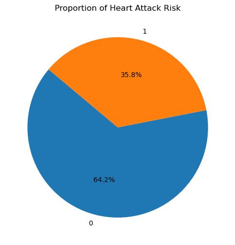

```python
plt.figure(figsize=(6, 6))
dataset[target_column].value_counts().plot.pie(autopct='%1.1f%%', startangle=140)
plt.title(f"Proportion of {target_column}")
plt.ylabel("")  # Hide the y-label
plt.show()
```

The proportion of the target variable, Heart Attack Risk, is 35.8% of presence of heart attack risk and 64.2% of no presence of heart attack risk.

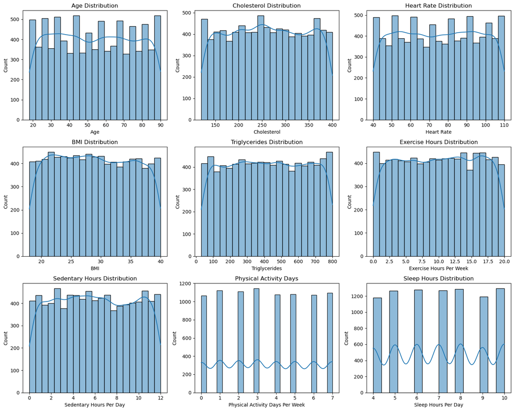

```python
# Plotting histograms for a few key numerical features
fig, axs = plt.subplots(3, 3, figsize=(15, 12))
sbn.histplot(dataset['Age'], kde=True, ax=axs[0, 0]).set(title="Age Distribution")
sbn.histplot(dataset['Cholesterol'], kde=True, ax=axs[0, 1]).set(title="Cholesterol Distribution")
sbn.histplot(dataset['Heart Rate'], kde=True, ax=axs[0, 2]).set(title="Heart Rate Distribution")
sbn.histplot(dataset['BMI'], kde=True, ax=axs[1, 0]).set(title="BMI Distribution")
sbn.histplot(dataset['Triglycerides'], kde=True, ax=axs[1, 1]).set(title="Triglycerides Distribution")
sbn.histplot(dataset['Exercise Hours Per Week'], kde=True, ax=axs[1, 2]).set(title="Exercise Hours Distribution")
sbn.histplot(dataset['Sedentary Hours Per Day'], kde=True, ax=axs[2, 0]).set(title="Sedentary Hours Distribution")
sbn.histplot(dataset['Physical Activity Days Per Week'], kde=True, ax=axs[2, 1]).set(title="Physical Activity Days")
sbn.histplot(dataset['Sleep Hours Per Day'], kde=True, ax=axs[2, 2]).set(title="Sleep Hours Distribution")
plt.tight_layout()
plt.show()
```

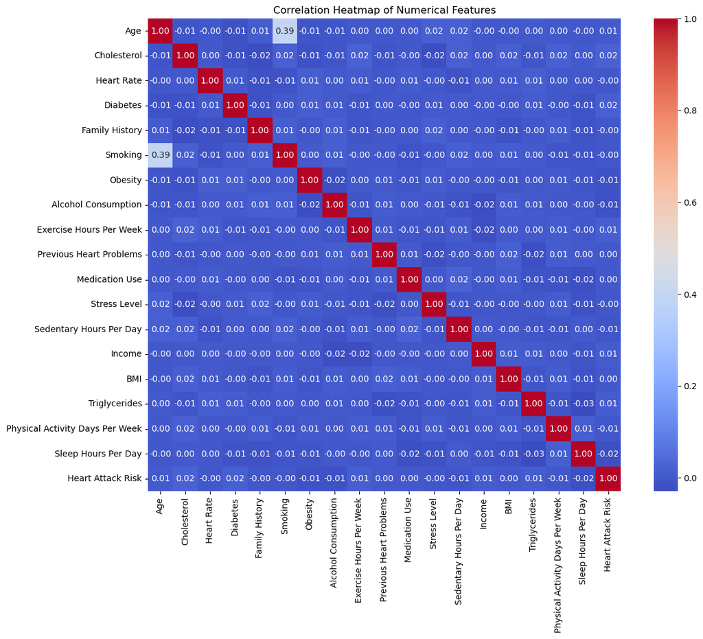

```python
# Correlation heatmap
numerical_data = dataset.select_dtypes(include=['int64', 'float64'])
plt.figure(figsize=(14, 10))
sbn.heatmap(numerical_data.corr(), annot=True, fmt=".2f", cmap="coolwarm", square=True)
plt.title("Correlation Heatmap of Numerical Features")
plt.show()
```

We check for any correlations between the numerical data, but we do not find any highly correlated features. There is only a slightly positive correlation between the smoking and the age of the patients of the dataset.

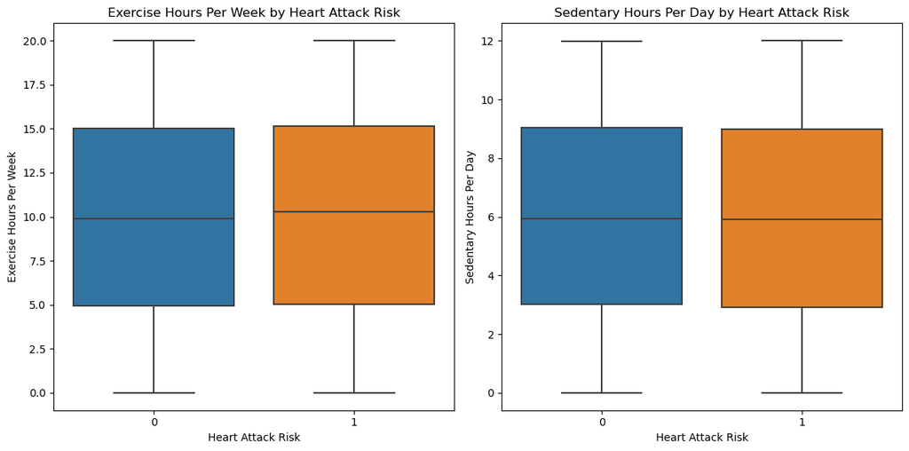

```python
# Plotting Exercise Hours and Sedentary Hours against Heart Attack Risk
fig, axs = plt.subplots(1, 2, figsize=(12, 6))

sbn.boxplot(x='Heart Attack Risk', y='Exercise Hours Per Week', data=dataset, ax=axs[0])
axs[0].set_title('Exercise Hours Per Week by Heart Attack Risk')

sbn.boxplot(x='Heart Attack Risk', y='Sedentary Hours Per Day', data=dataset, ax=axs[1])
axs[1].set_title('Sedentary Hours Per Day by Heart Attack Risk')

plt.tight_layout()
plt.show()
```

Define the function to calculate the metrics using the formulas from the slides.

```python
def calculate_metrics(y_true, y_pred):
    """
    Calculate evaluation metrics based on the confusion matrix.

    Parameters:
        y_true (list or array): True labels.
        y_pred (list or array): Predicted labels.

    Returns:
        pd.DataFrame: DataFrame containing the metrics.
    """
    # Get confusion matrix values
    tn, fp, fn, tp = confusion_matrix(y_true, y_pred).ravel()

    # Calculate metrics manually
    fpr = fp / (fp + tn) if (fp + tn) != 0 else 0
    fnr = fn / (fn + tp) if (fn + tp) != 0 else 0
    tss = (tp / (tp + fn) if (tp + fn) != 0 else 0) - fpr
    hss = (2 * (tp * tn - fp * fn)) / (
        ((tp + fn) * (fn + tn) + (tp + fp) * (fp + tn))
    ) if ((tp + fn) * (fn + tn) + (tp + fp) * (fp + tn)) != 0 else 0
    accuracy = (tp + tn) / (tp + tn + fp + fn)
    precision = tp / (tp + fp) if (tp + fp) != 0 else 0
    recall = tp / (tp + fn) if (tp + fn) != 0 else 0
    specificity = tn / (tn + fp) if (tn + fp) != 0 else 0
    f1 = (2 * precision * recall) / (precision + recall) if (precision + recall) != 0 else 0
    error_rate = 1 - accuracy
    balanced_acc = (recall + specificity) / 2


    # Store the metrics
    metrics = {
        "FPR" : fpr,
        "FNR" : fnr,
        "TSS" : tss,
        "HSS" : hss,
        "Accuracy" : accuracy,
        "Precision" : precision,
        "Recall/Sensitivity" : recall,
        "Specificity" : specificity,
        "F1 Measure" : f1,
        "Error Rate" : error_rate,
        "Balanced Accuracy" : balanced_acc
    }
    return metrics
```

We use LabelEncoder to convert the object variables into numbers so our models can use the data.

```python
# Initialize the LabelEncoder
label_encoder = LabelEncoder()

# Apply Label Encoding to each categorical column
for col in categorical_columns:
    dataset[col] = label_encoder.fit_transform(dataset[col])
```

```python
dataset.head()
```

| Patient ID | Age | Sex | Cholesterol | Blood Pressure | Heart Rate | Diabetes | Family History | Smoking | Obesity | Alcohol Consumption | ... | Sedentary Hours Per Day | Income | BMI | Triglycerides | Physical Activity Days Per Week | Sleep Hours Per Day | Country | Continent | Hemisphere | Heart Attack Risk |
| --- | --- | --- | --- | --- | --- | --- | --- | --- | --- | --- | --- | --- | --- | --- | --- | --- | --- | --- | --- | --- | --- |
| BMW7812 | 67 | 1 | 208 | 2510 | 72 | 0 | 0 | 1 | 0 | 0 | ... | 6.615001 | 261404 | 31.251233 | 286 | 0 | 6 | 0 | 5 | 1 | 0 |
| CZE1114 | 21 | 1 | 389 | 2815 | 98 | 1 | 1 | 1 | 1 | 1 | ... | 4.963459 | 285768 | 27.194973 | 235 | 1 | 7 | 3 | 4 | 0 | 0 |
| BNI9906 | 21 | 0 | 324 | 3224 | 72 | 1 | 0 | 0 | 0 | 0 | ... | 9.463426 | 235282 | 28.176571 | 587 | 4 | 4 | 6 | 3 | 0 | 0 |
| JLN3497 | 84 | 1 | 383 | 2689 | 73 | 1 | 1 | 1 | 0 | 1 | ... | 7.648981 | 125640 | 36.464704 | 378 | 3 | 4 | 3 | 4 | 0 | 0 |
| GFO8847 | 66 | 1 | 318 | 3563 | 93 | 1 | 1 | 1 | 1 | 0 | ... | 1.514821 | 160555 | 21.809144 | 231 | 1 | 5 | 16 | 1 | 0 | 0 |

5 rows × 25 columns

For a better use of the models, we standarize the numerical features using RobustScaler()

```python
# Standardize numerical features
scaler = RobustScaler()
dataset[numerical_columns] = scaler.fit_transform(dataset[numerical_columns])
```

```python
dataset.head()
```

| Patient ID | Age | Sex | Cholesterol | Blood Pressure | Heart Rate | Diabetes | Family History | Smoking | Obesity | Alcohol Consumption | ... | Sedentary Hours Per Day | Income | BMI | Triglycerides | Physical Activity Days Per Week | Sleep Hours Per Day | Country | Continent | Hemisphere | Heart Attack Risk |
| --- | --- | --- | --- | --- | --- | --- | --- | --- | --- | --- | --- | --- | --- | --- | --- | --- | --- | --- | --- | --- | --- |
| BMW7812 | 0.351351 | 1 | -0.369565 | 2510 | -0.083333 | -1.0 | 0.0 | 0.0 | -1.0 | -1.0 | ... | 0.113180 | 0.742533 | 0.227694 | -0.338939 | -1.000000 | -0.25 | 0 | 5 | 1 | 0.0 |
| CZE1114 | -0.891892 | 1 | 0.942029 | 2815 | 0.638889 | 0.0 | 1.0 | 0.0 | 0.0 | 0.0 | ... | -0.161148 | 0.917261 | -0.144385 | -0.470893 | -0.666667 | 0.00 | 3 | 4 | 0 | 0.0 |
| BNI9906 | -0.891892 | 0 | 0.471014 | 3224 | -0.083333 | 0.0 | 0.0 | -1.0 | -1.0 | -1.0 | ... | 0.586314 | 0.555196 | -0.054343 | 0.439845 | 0.333333 | -0.75 | 6 | 3 | 0 | 0.0 |
| JLN3497 | 0.810811 | 1 | 0.898551 | 2689 | -0.055556 | 0.0 | 1.0 | 0.0 | -1.0 | 0.0 | ... | 0.284928 | -0.231112 | 0.705924 | -0.100906 | 0.000000 | -0.75 | 3 | 4 | 0 | 0.0 |
| GFO8847 | 0.324324 | 1 | 0.427536 | 3563 | 0.500000 | 0.0 | 1.0 | 0.0 | 0.0 | -1.0 | ... | -0.733980 | 0.019284 | -0.638425 | -0.481242 | -0.666667 | -0.50 | 16 | 1 | 0 | 0.0 |

5 rows × 25 columns

```python
# Splitting features and target
X = dataset.drop(columns=['Heart Attack Risk'])
y = dataset['Heart Attack Risk']
```

```python
# Define the 10-fold cross-validator
kf = StratifiedKFold(n_splits=10, shuffle=True, random_state=42)
```

```python
randomforest = RandomForestClassifier(random_state=42)
KNN = KNeighborsClassifier()
```

```python
# Define parameter grids for hyperparameter tuning
KNN_param_grid = {
    'n_neighbors': [3, 5, 7, 9],
    'metric': ['euclidean', 'manhattan', 'minkowski']
}

randomforest_param_grid = {
    'n_estimators': [50, 100, 200],
    'max_depth': [None, 10, 20, 30]
}
```

```python
# Perform grid search for KNN
KNN_grid_search = GridSearchCV(KNN, KNN_param_grid, cv=5, verbose=1, n_jobs=-1)
KNN_grid_search.fit(X, y)
best_KNN = KNN_grid_search.best_estimator_
```

```
Fitting 5 folds for each of 12 candidates, totalling 60 fits
```

```python
best_KNN
```

```
KNeighborsClassifier(metric='euclidean', n_neighbors=9)
```

```python
# Perform grid search for Random Forest
randomforest_grid_search = GridSearchCV(randomforest, randomforest_param_grid, cv=5, verbose=1, n_jobs=-1)
randomforest_grid_search.fit(X, y)
best_randomforest = randomforest_grid_search.best_estimator_
```

```
Fitting 5 folds for each of 12 candidates, totalling 60 fits
```

```python
best_randomforest
```

```
RandomForestClassifier(max_depth=10, n_estimators=200, random_state=42)
```

```python
all_metrics = []
```

```python
# Loop through each fold
for fold, (train_index, test_index) in enumerate(kf.split(X, y)):
    print(f"----- Metrics for all Algorithms in Iteration {fold + 1} -----")

    # Split data
    X_train, X_test = X.iloc[train_index], X.iloc[test_index]
    y_train, y_test = y.iloc[train_index], y.iloc[test_index]

    # ---- Random Forest ----
    best_randomforest.fit(X_train, y_train)
    y_pred_randomforest = best_randomforest.predict(X_test)
    randomforest_metrics = calculate_metrics(y_test, y_pred_randomforest)

    # ---- KNN ----
    best_KNN.fit(X_train, y_train)
    y_pred_KNN = best_KNN.predict(X_test)
    KNN_metrics = calculate_metrics(y_test, y_pred_KNN)

    # ---- LSTM ----
    # Reshape for LSTM input (samples, timesteps, features)
    X_train_lstm = X_train.values.reshape(X_train.shape[0], 1, X_train.shape[1])
    X_test_lstm = X_test.values.reshape(X_test.shape[0], 1, X_test.shape[1])

    # Convert target to categorical for LSTM
    y_train_lstm = to_categorical(y_train, num_classes=2)
    y_test_lstm = to_categorical(y_test, num_classes=2)

    # Define LSTM model
    lstm_model = Sequential([
        Input(shape=(1, X_train.shape[1])),
        LSTM(64, activation='relu'),
        Dropout(0.2),
        Dense(2, activation='softmax')
    ])
    lstm_model.compile(optimizer='adam', loss='categorical_crossentropy', metrics=['accuracy'])
    lstm_model.fit(X_train_lstm, y_train_lstm, epochs=10, batch_size=16, verbose=0)

    y_pred_lstm = np.argmax(lstm_model.predict(X_test_lstm), axis=1)

    # Compute LSTM metrics
    lstm_metrics = calculate_metrics(y_test, y_pred_lstm)

    # ---- Combine Metrics ----
    all_metrics_fold = {
        'KNN': KNN_metrics,
        'Random Forest': randomforest_metrics,
        'LSTM': lstm_metrics
    }

    # Store metrics for the current fold
    all_metrics.append(all_metrics_fold)

    # ---- Print Metrics for All Algorithms in Current Iteration ----
    iteration_metrics = pd.DataFrame({
        'Metric': list(KNN_metrics.keys()),
        'KNN': list(KNN_metrics.values()),
        'Random Forest': list(randomforest_metrics.values()),
        'LSTM': list(lstm_metrics.values())
    })
    print(iteration_metrics.to_string(index=False))
```

```
----- Metrics for all Algorithms in Iteration 1 -----
28/28 ━━━━━━━━━━━━━━━━━━━━ 0s 10ms/step
            Metric       KNN  Random Forest     LSTM
               FPR  0.165187       0.000000 0.000000
               FNR  0.859873       1.000000 0.993631
               TSS -0.025059       0.000000 0.006369
               HSS -0.028628       0.000000 0.008163
          Accuracy  0.586089       0.641961 0.644242
         Precision  0.321168       0.000000 1.000000
Recall/Sensitivity  0.140127       0.000000 0.006369
       Specificity  0.834813       1.000000 1.000000
        F1 Measure  0.195122       0.000000 0.012658
        Error Rate  0.413911       0.358039 0.355758
 Balanced Accuracy  0.487470       0.500000 0.503185
----- Metrics for all Algorithms in Iteration 2 -----
28/28 ━━━━━━━━━━━━━━━━━━━━ 1s 9ms/step
            Metric       KNN  Random Forest     LSTM
               FPR  0.211368       0.000000 0.001776
               FNR  0.815287       1.000000 0.993631
               TSS -0.026654       0.000000 0.004593
               HSS -0.029501       0.000000 0.005881
          Accuracy  0.572406       0.641961 0.643101
         Precision  0.327684       0.000000 0.666667
Recall/Sensitivity  0.184713       0.000000 0.006369
       Specificity  0.788632       1.000000 0.998224
        F1 Measure  0.236253       0.000000 0.012618
        Error Rate  0.427594       0.358039 0.356899
 Balanced Accuracy  0.486673       0.500000 0.502297
----- Metrics for all Algorithms in Iteration 3 -----
28/28 ━━━━━━━━━━━━━━━━━━━━ 0s 8ms/step
            Metric       KNN  Random Forest     LSTM
               FPR  0.190053       0.000000 0.000000
               FNR  0.875796       1.000000 1.000000
               TSS -0.065849       0.000000 0.000000
               HSS -0.074686       0.000000 0.000000
          Accuracy  0.564424       0.641961 0.641961
         Precision  0.267123       0.000000 0.000000
Recall/Sensitivity  0.124204       0.000000 0.000000
       Specificity  0.809947       1.000000 1.000000
        F1 Measure  0.169565       0.000000 0.000000
```

[output cut: 85 more lines]

```
 Balanced Accuracy 0.511725       0.500000 0.500000
----- Metrics for all Algorithms in Iteration 10 -----
28/28 ━━━━━━━━━━━━━━━━━━━━ 0s 9ms/step
            Metric       KNN  Random Forest      LSTM
               FPR  0.197509       0.000000  0.001779
               FNR  0.831210       1.000000  1.000000
               TSS -0.028719       0.000000 -0.001779
               HSS -0.032103       0.000000 -0.002281
          Accuracy  0.575342       0.641553  0.640411
         Precision  0.323171       0.000000  0.000000
Recall/Sensitivity  0.168790       0.000000  0.000000
       Specificity  0.802491       1.000000  0.998221
        F1 Measure  0.221757       0.000000  0.000000
        Error Rate  0.424658       0.358447  0.359589
 Balanced Accuracy  0.485640       0.500000  0.499110
```

```python
def plot_individual_roc_curve(y_test, y_pred_probs, model_name):
    """
    Plot the ROC curve for an individual model.

    Parameters:
        y_test (array-like): True labels for the test set.
        y_pred_probs (array-like): Predicted probabilities for the positive class.
        model_name (str): Name of the model.
    """
    # Calculate ROC curve
    fpr, tpr, _ = roc_curve(y_test, y_pred_probs)
    # Calculate AUC
    roc_auc = auc(fpr, tpr)

    # Create the plot
    plt.figure(figsize=(8, 6))
    plt.plot(fpr, tpr, label=f'{model_name} (AUC = {roc_auc:.2f})', color='blue', lw=2)
    plt.plot([0, 1], [0, 1], color='red', linestyle='--')  # Diagonal line (random classifier)
    plt.xlim([0.0, 1.0])
    plt.ylim([0.0, 1.05])
    plt.xlabel('False Positive Rate (FPR)', fontsize=12)
    plt.ylabel('True Positive Rate (TPR)', fontsize=12)
    plt.title(f'ROC Curve - {model_name}', fontsize=16)
    plt.legend(loc='lower right', fontsize=10)
    plt.grid(True)
    plt.tight_layout()
    plt.show()
```

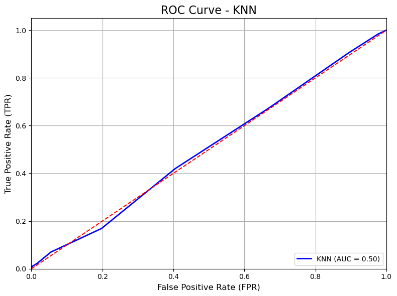

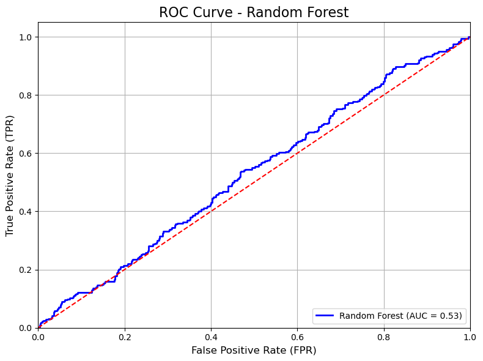

```
28/28 ━━━━━━━━━━━━━━━━━━━━ 0s 2ms/step
```

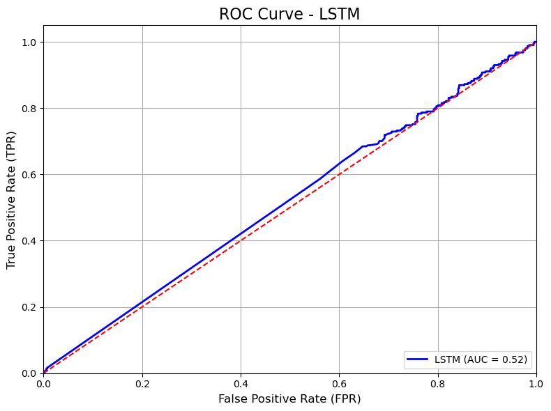

```python
# ---- KNN ----
y_pred_KNN_probs = best_KNN.predict_proba(X_test)[:, 1]  # Probability for class 1
plot_individual_roc_curve(y_test, y_pred_KNN_probs, 'KNN')

# ---- Random Forest ----
y_pred_randomforest_probs = best_randomforest.predict_proba(X_test)[:, 1]  # Probability for class 1
plot_individual_roc_curve(y_test, y_pred_randomforest_probs, 'Random Forest')

# ---- LSTM ----
y_pred_lstm_probs = lstm_model.predict(X_test_lstm)[:, 1]  # Probability for class 1
plot_individual_roc_curve(y_test, y_pred_lstm_probs, 'LSTM')
```

```
28/28 ━━━━━━━━━━━━━━━━━━━━ 0s 2ms/step
```

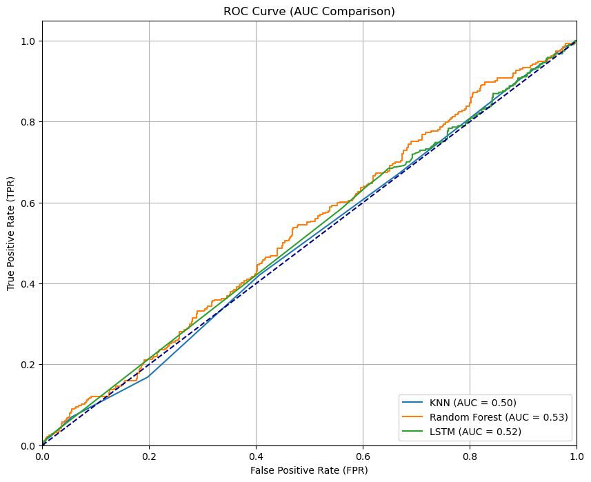

```python
# Function to plot ROC curve and AUC
def plot_roc_curve(y_test, y_pred_probs, model_name):
    # Calculate ROC curve
    fpr, tpr, _ = roc_curve(y_test, y_pred_probs)
    # Calculate AUC
    roc_auc = auc(fpr, tpr)

    # Plot ROC curve
    plt.plot(fpr, tpr, label=f'{model_name} (AUC = {roc_auc:.2f})')

# Initialize plot
plt.figure(figsize=(10, 8))

# ---- KNN ----
y_pred_knn_probs = best_KNN.predict_proba(X_test)[:, 1]  # Probability for class 1
plot_roc_curve(y_test, y_pred_knn_probs, 'KNN')

# ---- Random Forest ----
y_pred_rf_probs = best_randomforest.predict_proba(X_test)[:, 1]  # Probability for class 1
plot_roc_curve(y_test, y_pred_rf_probs, 'Random Forest')

# ---- LSTM ----
y_pred_lstm_probs = lstm_model.predict(X_test_lstm)[:, 1]  # Probability for class 1
plot_roc_curve(y_test, y_pred_lstm_probs, 'LSTM')

# Customize plot
plt.plot([0, 1], [0, 1], color='navy', linestyle='--')  # Diagonal line (random classifier)
plt.xlim([0.0, 1.0])
plt.ylim([0.0, 1.05])
plt.xlabel('False Positive Rate (FPR)')
plt.ylabel('True Positive Rate (TPR)')
plt.title('ROC Curve (AUC Comparison)')
plt.legend(loc='lower right')
plt.grid(True)

# Show the plot
plt.show()
```

```
Average Performance Across All Folds:
                Metric   KNN  Random Forest  LSTM
0                  FPR  0.19           0.00  0.00
1                  FNR  0.82           1.00  1.00
2                  TSS -0.01           0.00 -0.00
3                  HSS -0.01           0.00 -0.00
4             Accuracy  0.59           0.64  0.64
5            Precision  0.34           0.00  0.37
6   Recall/Sensitivity  0.18           0.00  0.00
7          Specificity  0.81           1.00  1.00
8           F1 Measure  0.23           0.00  0.00
9           Error Rate  0.41           0.36  0.36
10   Balanced Accuracy  0.49           0.50  0.50
```

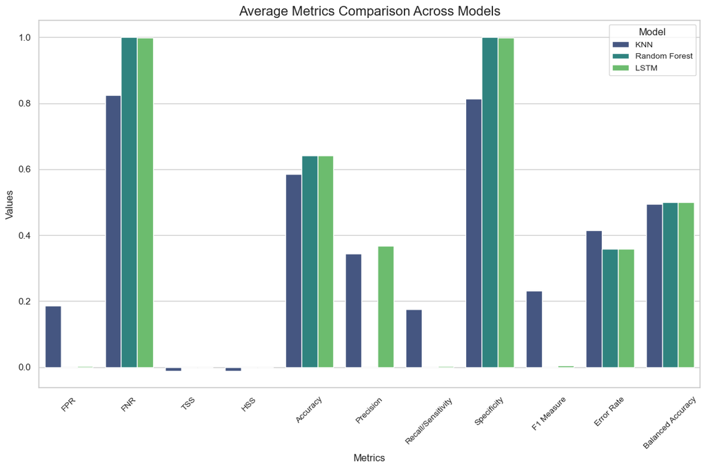

```python
# Initialize an empty dictionary to store average metrics for each model
average_metrics = {'Metric': []}

# Gather metrics for each model across folds
for model_name in ['KNN', 'Random Forest', 'LSTM']:
    # Extract all metric values for the current model from the folds
    metrics_by_model = {metric: [] for metric in all_metrics[0][model_name]}
    for fold_metrics in all_metrics:
        for metric, value in fold_metrics[model_name].items():
            metrics_by_model[metric].append(value)

    # Compute average metrics for the current model
    average_metrics['Metric'] = list(metrics_by_model.keys())
    average_metrics[model_name] = [sum(values) / len(values) for values in metrics_by_model.values()]

# Convert the average metrics dictionary to a DataFrame
avg_performance_df = pd.DataFrame(average_metrics)

# Print the DataFrame
print("Average Performance Across All Folds:")
print(avg_performance_df.round(decimals=2))

# Create a bar plot for the metrics comparison
plt.figure(figsize=(12, 8))
sbn.set_theme(style="whitegrid")

# Melt the DataFrame for plotting
melted_df = avg_performance_df.melt(id_vars='Metric', var_name='Model', value_name='Value')

# Plot the data using seaborn
sbn.barplot(data=melted_df, x='Metric', y='Value', hue='Model', palette='viridis')

# Customize the plot
plt.title('Average Metrics Comparison Across Models', fontsize=16)
plt.xlabel('Metrics', fontsize=12)
plt.ylabel('Values', fontsize=12)
plt.xticks(rotation=45, fontsize=10)
plt.legend(title='Model', fontsize=10)
plt.tight_layout()

# Show the plot
plt.show()
```

In this experiment, we can observe that the models do not achieve a high accuracy. In general terms, the models predict pretty well the cases where there is no risk of a heart attack (the negative cases), but struggle to predict correctly the positive cases. This is pretty bad because a good model in the healthcare industry should predict and be focused when there is a risk of heart attack to try to prevent it.

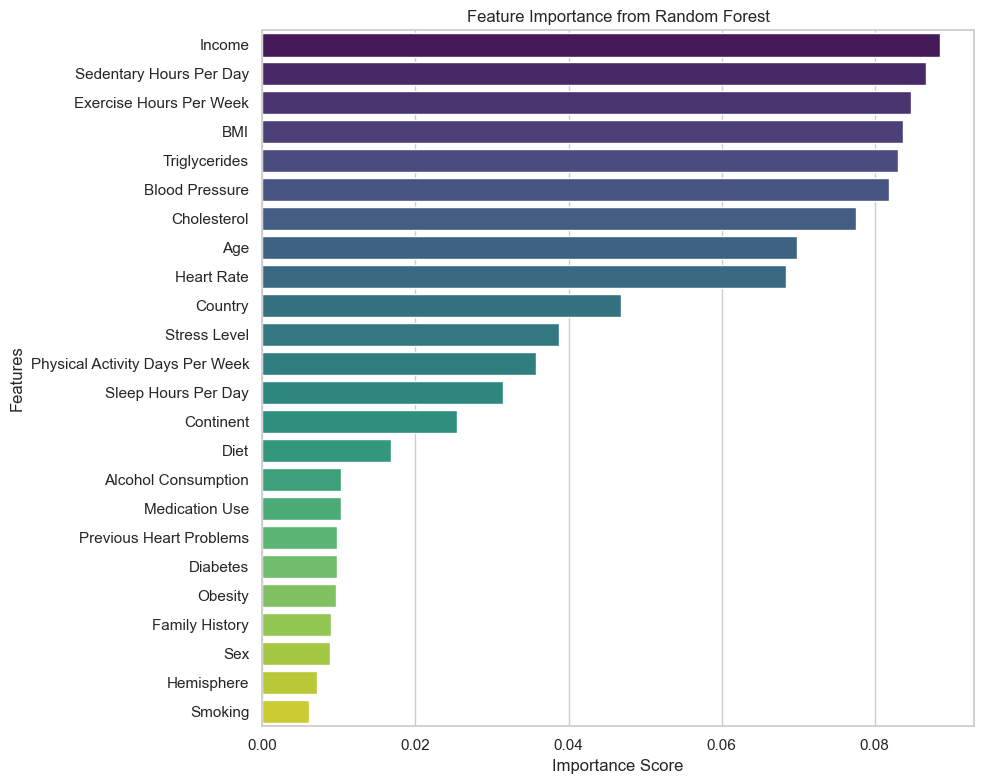

```python
# Random Forest Feature Selection
importances = best_randomforest.feature_importances_
feature_names = X.columns

# Create a DataFrame for better visualization
feature_importance_df = pd.DataFrame({
    'Feature': feature_names,
    'Importance': importances
}).sort_values(by='Importance', ascending=False)

# Plot the feature importances
plt.figure(figsize=(10, 8))
sbn.barplot(x='Importance', y='Feature', data=feature_importance_df, palette="viridis")
plt.title('Feature Importance from Random Forest')
plt.xlabel('Importance Score')
plt.ylabel('Features')
plt.tight_layout()
plt.show()
```

We check for feature importance and we reduce the size of features in the training data, focusing on the most important ones.

```python
# Select top 10 features
top_10_features = feature_importance_df.head(10)['Feature'].tolist()

# Update dataset with only the top 10 features
X_top_10 = X[top_10_features]

# Print selected features
print("Top 10 Features Selected:")
print(top_10_features)
```

```
Top 10 Features Selected:
['Income', 'Sedentary Hours Per Day', 'Exercise Hours Per Week', 'BMI', 'Triglycerides', 'Blood Pressure', 'Cholesterol', 'Age', 'Heart Rate', 'Country']
```

```python
# Initialize SMOTE
smote = SMOTE(random_state=42)

# Apply SMOTE to the reduced dataset (X_top_10)
X_smote, y_smote = smote.fit_resample(X_top_10, y)

# Display the new class distribution
from collections import Counter
print(f"Class distribution after SMOTE: {Counter(y_smote)}")
```

```
Class distribution after SMOTE: Counter({0.0: 5624, 1.0: 5624})
```

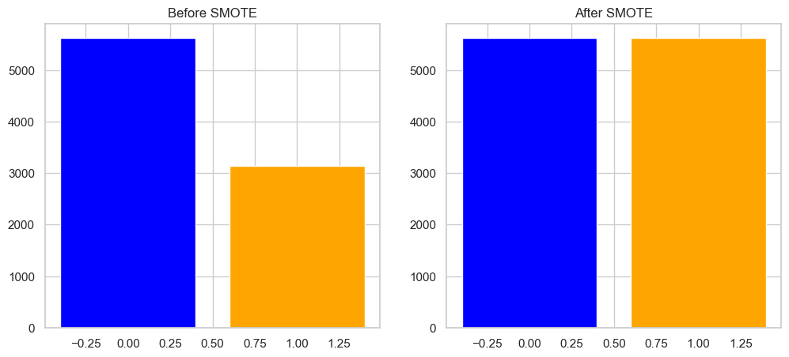

```python
# Plot class distribution before and after SMOTE
fig, ax = plt.subplots(1, 2, figsize=(12, 5))
ax[0].bar(Counter(y).keys(), Counter(y).values(), color=['blue', 'orange'])
ax[0].set_title('Before SMOTE')
ax[1].bar(Counter(y_smote).keys(), Counter(y_smote).values(), color=['blue', 'orange'])
ax[1].set_title('After SMOTE')
plt.show()
```

```python
# Perform cross-validation with top 10 features
for fold, (train_index, test_index) in enumerate(kf.split(X_top_10, y)):
    print(f"----- Metrics for all Algorithms in Iteration {fold + 1} -----")

    # Split data
    X_train, X_test = X_top_10.iloc[train_index], X_top_10.iloc[test_index]
    y_train, y_test = y_smote.iloc[train_index], y_smote.iloc[test_index]

    # ---- Random Forest ----
    best_randomforest.fit(X_train, y_train)
    y_pred_randomforest = best_randomforest.predict(X_test)
    randomforest_metrics = calculate_metrics(y_test, y_pred_randomforest)

    # ---- KNN ----
    best_KNN.fit(X_train, y_train)
    y_pred_KNN = best_KNN.predict(X_test)
    KNN_metrics = calculate_metrics(y_test, y_pred_KNN)


    # ---- LSTM ----
    X_train_lstm = X_train.values.reshape(X_train.shape[0], 1, X_train.shape[1])
    X_test_lstm = X_test.values.reshape(X_test.shape[0], 1, X_test.shape[1])
    y_train_lstm = to_categorical(y_train, num_classes=2)
    y_test_lstm = to_categorical(y_test, num_classes=2)

    lstm_model = Sequential([
        Input(shape=(1, X_train.shape[1])),
        LSTM(64, activation='relu'),
        Dropout(0.2),
        Dense(2, activation='softmax')
    ])
    lstm_model.compile(optimizer='adam', loss='categorical_crossentropy', metrics=['accuracy'])
    lstm_model.fit(X_train_lstm, y_train_lstm, epochs=10, batch_size=16, verbose=0)

    y_pred_lstm = np.argmax(lstm_model.predict(X_test_lstm), axis=1)
    lstm_metrics = calculate_metrics(y_test, y_pred_lstm)

    # ---- Combine Metrics ----
    all_metrics_fold = {
        'KNN': KNN_metrics,
        'Random Forest': randomforest_metrics,
        'LSTM': lstm_metrics
    }

    # Store metrics for the current fold
    all_metrics.append(all_metrics_fold)

    # ---- Print Metrics for All Algorithms in Current Iteration ----
    iteration_metrics = pd.DataFrame({
        'Metric': list(KNN_metrics.keys()),
        'KNN': list(KNN_metrics.values()),
        'Random Forest': list(randomforest_metrics.values()),
        'LSTM': list(lstm_metrics.values())
    })
    print(iteration_metrics.to_string(index=False))
```

[output not shown]

[output cut: 85 more lines]

```
 Balanced Accuracy 0.517063       0.500000 0.500000
----- Metrics for all Algorithms in Iteration 10 -----
28/28 ━━━━━━━━━━━━━━━━━━━━ 1s 16ms/step
            Metric       KNN  Random Forest     LSTM
               FPR  0.179715       0.000000 0.000000
               FNR  0.834395       0.996815 1.000000
               TSS -0.014110       0.003185 0.000000
               HSS -0.015910       0.004083 0.000000
          Accuracy  0.585616       0.642694 0.641553
         Precision  0.339869       1.000000 0.000000
Recall/Sensitivity  0.165605       0.003185 0.000000
       Specificity  0.820285       1.000000 1.000000
        F1 Measure  0.222698       0.006349 0.000000
        Error Rate  0.414384       0.357306 0.358447
 Balanced Accuracy  0.492945       0.501592 0.500000
```

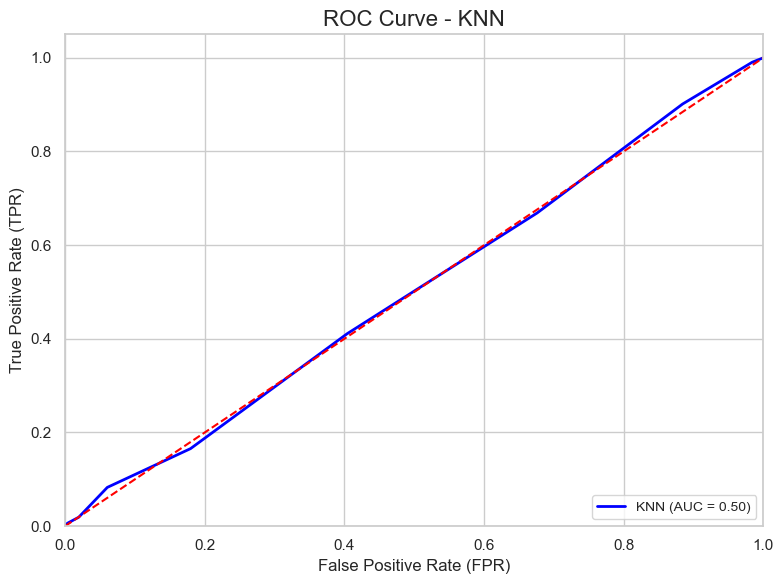

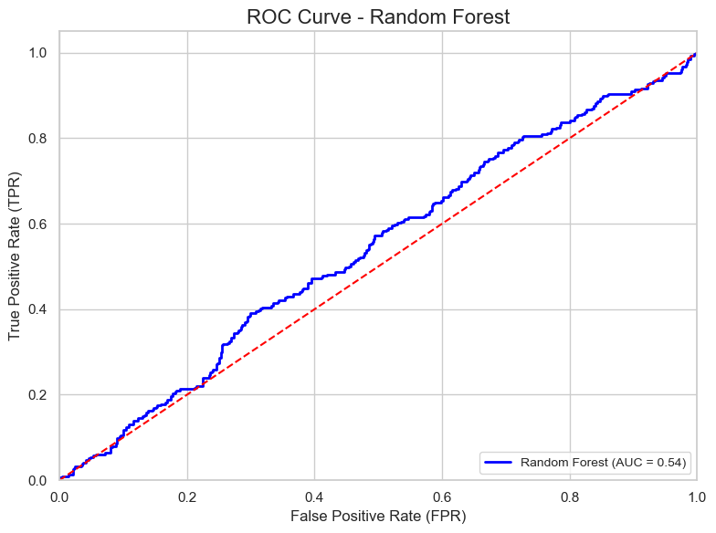

```
28/28 ━━━━━━━━━━━━━━━━━━━━ 0s 2ms/step
```

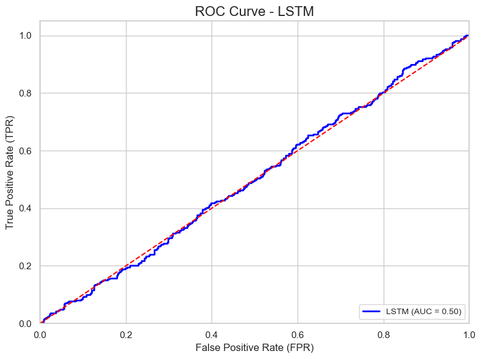

```python
# ---- KNN ----
y_pred_KNN_probs = best_KNN.predict_proba(X_test)[:, 1]  # Probability for class 1
plot_individual_roc_curve(y_test, y_pred_KNN_probs, 'KNN')

# ---- Random Forest ----
y_pred_randomforest_probs = best_randomforest.predict_proba(X_test)[:, 1]  # Probability for class 1
plot_individual_roc_curve(y_test, y_pred_randomforest_probs, 'Random Forest')

# ---- LSTM ----
y_pred_lstm_probs = lstm_model.predict(X_test_lstm)[:, 1]  # Probability for class 1
plot_individual_roc_curve(y_test, y_pred_lstm_probs, 'LSTM')
```

```
28/28 ━━━━━━━━━━━━━━━━━━━━ 0s 2ms/step
```

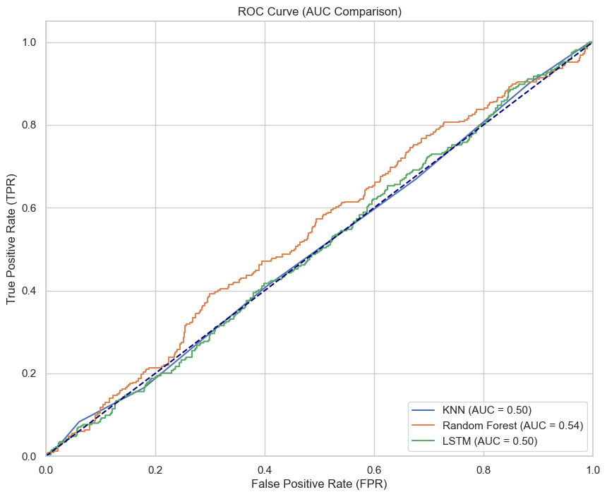

```python
# Initialize plot
plt.figure(figsize=(10, 8))

# ---- KNN ----
y_pred_knn_probs = best_KNN.predict_proba(X_test)[:, 1]  # Probability for class 1
plot_roc_curve(y_test, y_pred_knn_probs, 'KNN')

# ---- Random Forest ----
y_pred_rf_probs = best_randomforest.predict_proba(X_test)[:, 1]  # Probability for class 1
plot_roc_curve(y_test, y_pred_rf_probs, 'Random Forest')

# ---- LSTM ----
y_pred_lstm_probs = lstm_model.predict(X_test_lstm)[:, 1]  # Probability for class 1
plot_roc_curve(y_test, y_pred_lstm_probs, 'LSTM')

# Customize plot
plt.plot([0, 1], [0, 1], color='navy', linestyle='--')  # Diagonal line (random classifier)
plt.xlim([0.0, 1.0])
plt.ylim([0.0, 1.05])
plt.xlabel('False Positive Rate (FPR)')
plt.ylabel('True Positive Rate (TPR)')
plt.title('ROC Curve (AUC Comparison)')
plt.legend(loc='lower right')
plt.grid(True)

# Show the plot
plt.show()
```

```
Average Performance Across All Folds:
                Metric   KNN  Random Forest  LSTM
0                  FPR  0.18           0.00  0.00
1                  FNR  0.82           1.00  1.00
2                  TSS -0.01          -0.00  0.00
3                  HSS -0.01          -0.00  0.00
4             Accuracy  0.59           0.64  0.64
5            Precision  0.35           0.05  0.22
6   Recall/Sensitivity  0.18           0.00  0.00
7          Specificity  0.82           1.00  1.00
8           F1 Measure  0.23           0.00  0.00
9           Error Rate  0.41           0.36  0.36
10   Balanced Accuracy  0.50           0.50  0.50
```

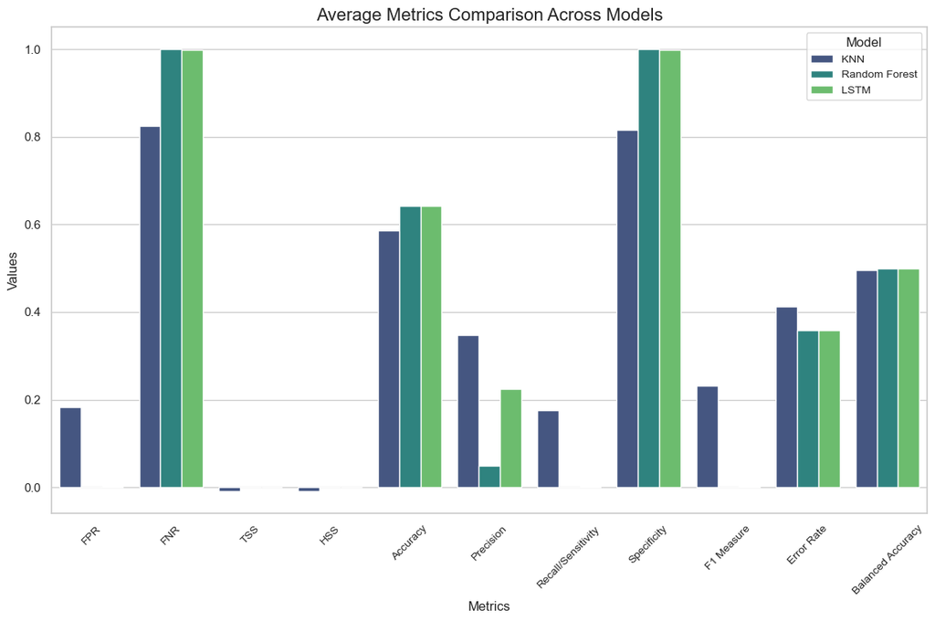

```python
# Initialize an empty dictionary to store average metrics for each model
average_metrics = {'Metric': []}

# Gather metrics for each model across folds
for model_name in ['KNN', 'Random Forest', 'LSTM']:
    # Extract all metric values for the current model from the folds
    metrics_by_model = {metric: [] for metric in all_metrics[0][model_name]}
    for fold_metrics in all_metrics:
        for metric, value in fold_metrics[model_name].items():
            metrics_by_model[metric].append(value)

    # Compute average metrics for the current model
    average_metrics['Metric'] = list(metrics_by_model.keys())
    average_metrics[model_name] = [sum(values) / len(values) for values in metrics_by_model.values()]

# Convert the average metrics dictionary to a DataFrame
avg_performance_df = pd.DataFrame(average_metrics)

# Print the DataFrame
print("Average Performance Across All Folds:")
print(avg_performance_df.round(decimals=2))

# Create a bar plot for the metrics comparison
plt.figure(figsize=(12, 8))
sbn.set_theme(style="whitegrid")

# Melt the DataFrame for plotting
melted_df = avg_performance_df.melt(id_vars='Metric', var_name='Model', value_name='Value')

# Plot the data using seaborn
sbn.barplot(data=melted_df, x='Metric', y='Value', hue='Model', palette='viridis')

# Customize the plot
plt.title('Average Metrics Comparison Across Models', fontsize=16)
plt.xlabel('Metrics', fontsize=12)
plt.ylabel('Values', fontsize=12)
plt.xticks(rotation=45, fontsize=10)
plt.legend(title='Model', fontsize=10)
plt.tight_layout()

# Show the plot
plt.show()
```

## Side Notes

To be able to run this code make sure to have installed the following libraries: pandas, numpy, seaborn, matplotlib, sklearn, tensorflow and imbalanced-learn.  
To install the libraries write the following in the terminal: pip install (name of the library).  
Another way to install the libraries is to write in a cell of the jupiter notebook: !pip install (name of the library).  
Moreover, it is important to have the required csv file, jupiter notebook, and python file in the same folder in order to run the codes.

https://github.com/psalarc/salar_pablo_finaltermproj